# NLP_FULL_CODE_PROJECT

## **Problem Statement**

### Business Context

The prices of the stocks of companies listed under a global exchange are influenced by a variety of factors, with the company's financial performance, innovations and collaborations, and market sentiment being factors that play a significant role. News and media reports can rapidly affect investor perceptions and, consequently, stock prices in the highly competitive financial industry. With the sheer volume of news and opinions from a wide variety of sources, investors and financial analysts often struggle to stay updated and accurately interpret its impact on the market. As a result, investment firms need sophisticated tools to analyze market sentiment and integrate this information into their investment strategies.

### Problem Definition

With an ever-rising number of news articles and opinions, an investment startup aims to leverage artificial intelligence to address the challenge of interpreting stock-related news and its impact on stock prices. They have collected historical daily news for a specific company listed under NASDAQ, along with data on its daily stock price and trade volumes.

As a member of the Data Science and AI team in the startup, you have been tasked with analyzing the data, developing an AI-driven sentiment analysis system that will automatically process and analyze news articles to gauge market sentiment, and summarizing the news at a weekly level to enhance the accuracy of their stock price predictions and optimize investment strategies. This will empower their financial analysts with actionable insights, leading to more informed investment decisions and improved client outcomes.

### Data Dictionary

- `Date` : The date the news was released
- `News` : The content of news articles that could potentially affect the company's stock price
- `Open` : The stock price (in \$) at the beginning of the day
- `High` : The highest stock price (in \$) reached during the day
- `Low` : The lowest stock price (in \$) reached during the day
- `Close` : The adjusted stock price (in \$) at the end of the day
- `Volume` : The number of shares traded during the day
- `Label` : The sentiment polarity of the news content
  - 1: positive
  - 0: neutral
  - -1: negative

## **Installing and Importing Necessary Libraries**

```python
# installing the sentence-transformers and gensim libraries for word embeddings
!pip install -U sentence-transformers gensim transformers tqdm -q
!pip install huggingface_hub==0.25.0 -q

# to read and manipulate the data
import pandas as pd
import numpy as np
pd.set_option('max_colwidth', None)    # setting column to the maximum column width as per the data

# to visualise data
import matplotlib.pyplot as plt
import seaborn as sns

# to compute distances
from scipy.spatial.distance import cdist, pdist
from sklearn.metrics import silhouette_score

# importing the PyTorch Deep Learning library
import torch

# to import the model
from sentence_transformers import SentenceTransformer

# to cluster the data
from sklearn.cluster import KMeans

# to compute metrics
from sklearn.metrics import classification_report

# to avoid displaying unnecessary warnings
import warnings
warnings.filterwarnings("ignore")

# Function to download the model from the Hugging Face model hub
from huggingface_hub import hf_hub_download

# Importing the json module
import json

# to use regular expressions for manipulating text data
import re

# to load the natural language toolkit
import nltk
nltk.download('stopwords')    # loading the stopwords
nltk.download('wordnet')    # loading the wordnet module that is used in stemming

# to remove common stop words
from nltk.corpus import stopwords

# to perform stemming
from nltk.stem.porter import PorterStemmer

# To encode the target variable
from sklearn.preprocessing import LabelEncoder

# To import Word2Vec
from gensim.models import Word2Vec

# To tune the model
from sklearn.model_selection import GridSearchCV

# Converting the Stanford GloVe model vector format to word2vec
from gensim.scripts.glove2word2vec import glove2word2vec
from gensim.models import KeyedVectors

# To split data into train and test sets
from sklearn.model_selection import train_test_split

# To build a Random Forest model
from sklearn.ensemble import RandomForestClassifier

# To compute metrics to evaluate the model
from sklearn.metrics import confusion_matrix, accuracy_score, f1_score, precision_score, recall_score, classification_report
```

```
     ━━━━━━━━━━━━━━━━━━━━━━━━━━━━━━━━━━━━━━━━ 44.4/44.4 kB 3.3 MB/s eta 0:00:00
   ━━━━━━━━━━━━━━━━━━━━━━━━━━━━━━━━━━━━━━━━ 9.7/9.7 MB 48.0 MB/s eta 0:00:00
   ━━━━━━━━━━━━━━━━━━━━━━━━━━━━━━━━━━━━━━━━ 436.4/436.4 kB 10.0 MB/s eta 0:00:00
```

## **Loading the dataset**

```python
from google.colab import drive
drive.mount('/content/drive')

filepath = '/content/drive/My Drive/stock_news.csv'
df = pd.read_csv(filepath)
```

## **Data Overview**

```python
data = df.copy()
data.head()
```

|  | Date | News | Open | High | Low | Close | Volume | Label |
| --- | --- | --- | --- | --- | --- | --- | --- | --- |
| 0 | 2019-01-02 | The tech sector experienced a significant dec... | 41.740002 | 42.244999 | 41.482498 | 40.246914 | 130672400 | -1 |
| 1 | 2019-01-02 | Apple lowered its fiscal Q1 revenue guidance ... | 41.740002 | 42.244999 | 41.482498 | 40.246914 | 130672400 | -1 |
| 2 | 2019-01-02 | Apple cut its fiscal first quarter revenue fo... | 41.740002 | 42.244999 | 41.482498 | 40.246914 | 130672400 | -1 |
| 3 | 2019-01-02 | This news article reports that yields on long... | 41.740002 | 42.244999 | 41.482498 | 40.246914 | 130672400 | -1 |
| 4 | 2019-01-02 | Apple's revenue warning led to a decline in U... | 41.740002 | 42.244999 | 41.482498 | 40.246914 | 130672400 | -1 |

```python
data.loc[0, 'News']
```

```
" The tech sector experienced a significant decline in the aftermarket following Apple's Q1 revenue warning. Notable suppliers, including Skyworks, Broadcom, Lumentum, Qorvo, and TSMC, saw their stocks drop in response to Apple's downward revision of its revenue expectations for the quarter, previou…
```

```python
data.shape
```

```
(349, 8)
```

Data comprised of 349 news articles

```python
data.isnull().sum()
```

|  | 0 |
| --- | --- |
| Date | 0 |
| News | 0 |
| Open | 0 |
| High | 0 |
| Low | 0 |
| Close | 0 |
| Volume | 0 |
| Label | 0 |

**dtype:** int64

No missing values in data

```python
data.duplicated().sum()
```

```
0
```

```python
data['Date']=pd.to_datetime(data['Date'])
```

```python
data.describe()
```

|  | Date | Open | High | Low | Close | Volume | Label |
| --- | --- | --- | --- | --- | --- | --- | --- |
| count | 349 | 349.000000 | 349.000000 | 349.000000 | 349.000000 | 3.490000e+02 | 349.000000 |
| mean | 2019-02-16 16:05:30.085959936 | 46.229233 | 46.700458 | 45.745394 | 44.926317 | 1.289482e+08 | -0.054441 |
| min | 2019-01-02 00:00:00 | 37.567501 | 37.817501 | 37.305000 | 36.254131 | 4.544800e+07 | -1.000000 |
| 25% | 2019-01-14 00:00:00 | 41.740002 | 42.244999 | 41.482498 | 40.246914 | 1.032720e+08 | -1.000000 |
| 50% | 2019-02-05 00:00:00 | 45.974998 | 46.025002 | 45.639999 | 44.596924 | 1.156272e+08 | 0.000000 |
| 75% | 2019-03-22 00:00:00 | 50.707500 | 50.849998 | 49.777500 | 49.110790 | 1.511252e+08 | 0.000000 |
| max | 2019-04-30 00:00:00 | 66.817497 | 67.062500 | 65.862503 | 64.805229 | 2.444392e+08 | 1.000000 |
| std | NaN | 6.442817 | 6.507321 | 6.391976 | 6.398338 | 4.317031e+07 | 0.715119 |

- Average sentiment polarity of article is slightly negative
- Reports are from beginning of January to end of April (around 4 months)
- Average ~130 million stock per day

## **Exploratory Data Analysis**

### Univariate Analysis

- Distribution of individual variables
- Compute and check the distribution of the length of news content

```python
def labeled_barplot(data, feature, perc=False, n=None):
    """
    Barplot with percentage at the top

    data: dataframe
    feature: dataframe column
    perc: whether to display percentages instead of count (default is False)
    n: displays the top n category levels (default is None, i.e., display all levels)
    """

    total = len(data[feature])  # length of the column
    count = data[feature].nunique()
    if n is None:
        plt.figure(figsize=(count + 1, 5))
    else:
        plt.figure(figsize=(n + 1, 5))

    plt.xticks(rotation=90, fontsize=15)
    ax = sns.countplot(
        data=data,
        x=feature,
        palette="Paired",
        order=data[feature].value_counts().index[:n].sort_values(),
    )

    for p in ax.patches:
        if perc == True:
            label = "{:.1f}%".format(
                100 * p.get_height() / total
            )  # percentage of each class of the category
        else:
            label = p.get_height()  # count of each level of the category

        x = p.get_x() + p.get_width() / 2  # width of the plot
        y = p.get_height()  # height of the plot

        ax.annotate(
            label,
            (x, y),
            ha="center",
            va="center",
            size=12,
            xytext=(0, 5),
            textcoords="offset points",
        )  # annotate the percentage

    plt.show()  # show the plot
```

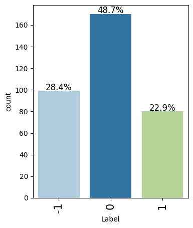

```python
labeled_barplot(data, 'Label', perc=True)
```

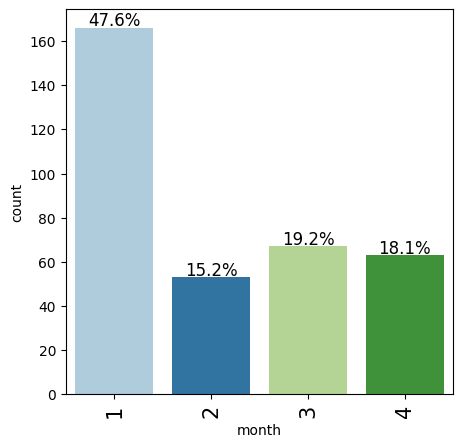

```python
data['month'] = pd.to_datetime(data['Date']).dt.month
labeled_barplot(data, 'month', perc=True)
```

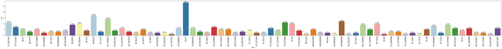

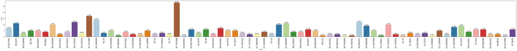

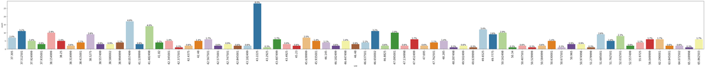

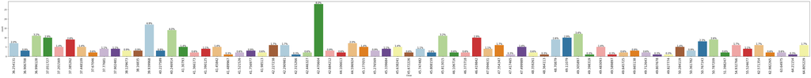

```python
labeled_barplot(data, 'Open', perc=True)
labeled_barplot(data, 'High', perc=True)
labeled_barplot(data, 'Low', perc=True)
labeled_barplot(data, 'Close', perc=True)
```

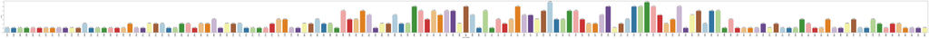

```python
data['news_length'] = data['News'].astype(str).apply(len)
labeled_barplot(data, 'news_length', perc=True)
```

large distribution of news length

### Bivariate Analysis

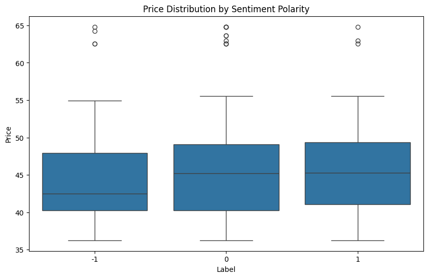

```python
plt.figure(figsize=(10, 6))
sns.boxplot(x='Label', y='Close', data=df)
plt.title('Price Distribution by Sentiment Polarity')
plt.xlabel('Label')
plt.ylabel('Price')
plt.show()
```

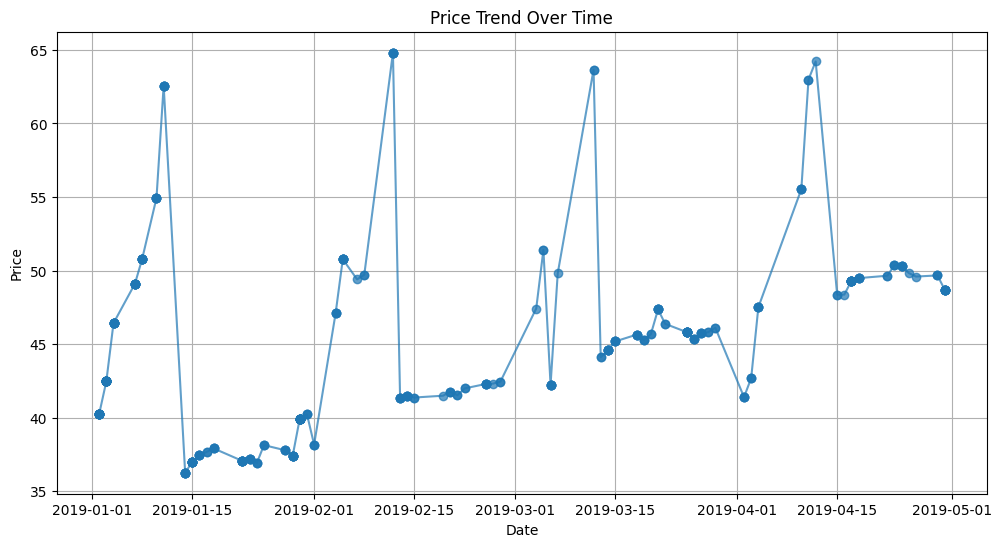

```python
# Plot price trend over time
plt.figure(figsize=(12, 6))
plt.plot(data['Date'], data['Close'], marker='o', linestyle='-', alpha=0.7)
plt.title('Price Trend Over Time')
plt.xlabel('Date')
plt.ylabel('Price')
plt.grid(True)
plt.show()
```

- Correlation
- Sentiment Polarity vs Price
- Date vs Price

**Note**: The above points are listed to provide guidance on how to approach bivariate analysis. Analysis has to be done beyond the above listed points to get maximum scores.

```python
cols = ['Open', 'High', 'Low', 'Close', 'Volume']
sns.heatmap(data[cols].corr(), annot=True, cmap='coolwarm')
plt.show()
```

[output not shown]

## **Data Preprocessing**

```python
dataset2 = data.copy()
dataset3 = data.copy()
```

Sentence Transformer

```python
sentence_model = SentenceTransformer('sentence-transformers/all-MiniLM-L6-v2')
```

```python
# setting the device to GPU if available, else CPU
device = torch.device("cuda" if torch.cuda.is_available() else "cpu")
```

```python
# encoding the dataset
embedding_matrix = sentence_model.encode(dataset3['News'], device=device, show_progress_bar=True)
```

```python
# printing the shape of the embedding matrix
embedding_matrix.shape
```

```
(349, 384)
```

```python
# printing the embedding vector of the first news article in the dataset
embedding_matrix[0,:]
```

```
array([-2.02308688e-03, -3.67735364e-02,  7.73542598e-02,  4.67134081e-02,
        3.25521305e-02,  2.10231193e-03,  4.32834737e-02,  3.95344906e-02,
        5.82279935e-02,  8.87513440e-03,  7.09636807e-02,  4.99076843e-02,
        6.46608099e-02, -4.97970264e-03, -1.30518479e-02, -2.98355557e-02,
       -8.91322084e-03, -7.82000348e-02, -2.17109658e-02, -5.24822623e-02,
       -5.14276549e-02, -3.30719985e-02, -3.32051516e-02,  4.18125615e-02,
        7.99547583e-02,  1.54092284e-02, -2.15781443e-02,  5.19438535e-02,
       -4.65799086e-02, -3.71372141e-02, -1.04225606e-01,  9.86078903e-02,
        5.21786399e-02,  3.46578993e-02,  1.48809813e-02, -4.47350414e-03,
        5.70117794e-02, -2.41722930e-02,  2.14048829e-02, -6.52144775e-02,
       -3.30645032e-02,  1.61960777e-02, -6.63141608e-02,  4.39943299e-02,
        3.82153168e-02, -4.86519411e-02,  1.62651073e-02, -4.02665772e-02,
       -3.34568229e-03,  3.20955738e-02, -3.91200650e-03, -1.26830470e-02,
        4.49698754e-02,  3.39314081e-02, -5.17101809e-02,  5.32578826e-02,
       -4.53628600e-02, -2.19655819e-02,  7.14351833e-02,  3.10435817e-02,
        4.33289856e-02, -9.26511064e-02,  1.73018910e-02, -8.11785087e-03,
        6.26880452e-02, -1.42353158e-02, -4.14227284e-02,  5.68226501e-02,
       -8.62419307e-02,  6.02035522e-02,  4.75493930e-02, -7.17870072e-02,
        1.17750419e-02,  4.39625569e-02, -3.44558358e-02,  3.67184021e-02,
        5.21757454e-02, -2.14000400e-02, -5.96954022e-03,  8.72079656e-03,
        3.53135467e-02, -3.95235457e-02, -9.36869308e-02,  1.56855937e-02,
       -3.84228751e-02,  2.47944966e-02,  3.62802781e-02, -1.32978177e-02,
       -4.67082486e-02, -5.69416471e-02,  6.84317723e-02, -2.25550658e-03,
        1.43187074e-02, -1.19597111e-02,  5.61927594e-02, -5.40325232e-02,
        1.84007827e-02, -9.87436026e-02,  1.36832474e-02,  1.76982135e-02,
        4.83816527e-02,  3.39467935e-02,  5.20425402e-02, -3.35446149e-02,
       -4.39126827e-02, -9.73524675e-02,  4.13890406e-02,  2.77670706e-03,
        3.94195206e-02,  1.73664875e-02, -2.37191021e-02,  1.02214050e-02,
       -5.20212874e-02, -4.82435077e-02, -6.77878410e-02,  7.58207291e-02,
       -1.03107914e-02,  6.10160008e-02, -4.92668599e-02, -1.84614286e-02,
       -5.64168356e-02,  6.09038062e-02, -4.93265828e-03,  1.02207344e-02,
        3.61768417e-02,  1.62944254e-02, -1.01151675e-01, -9.37196024e-34,
        1.30963568e-02,  2.90462077e-02, -5.68401664e-02, -1.07232621e-02,
        3.43215726e-02, -5.42571954e-02,  6.12289645e-02,  6.73203496e-03,
       -6.39356300e-02, -3.71847749e-02, -4.51456308e-02,  5.50827645e-02,
       -5.48340753e-02, -9.50715691e-02,  7.80199915e-02, -1.12085916e-01,
       -5.90517521e-02, -8.70311912e-03,  6.69128373e-02, -2.09151953e-02,
       -4.48345281e-02, -6.54890388e-02, -5.31035922e-02,  6.96217045e-02,
        8.78782757e-03,  7.72807980e-04,  1.89882703e-03,  3.55078094e-02,
        1.91084370e-02,  2.86549870e-02, -5.54806180e-02,  6.67085126e-02,
```

[output cut: 42 more lines]

```
        1.08690090e-01,  3.81879359e-02, -7.81213790e-02, -1.09489430e-02,
       -1.17989458e-01,  7.97276795e-02,  2.46654917e-02,  9.32490744e-04,
       -7.25726709e-02,  8.93294718e-03,  4.05104943e-02, -1.03700548e-01,
       -6.20276993e-03,  3.49569283e-02,  7.82294050e-02, -2.42466442e-02,
       -3.33974361e-02,  3.95032912e-02,  1.34983344e-03, -7.48429075e-02,
        5.03437705e-02,  5.74472127e-03, -2.39702631e-02,  1.32117537e-03,
        6.57341480e-02, -5.62656298e-02, -6.76571950e-02, -4.22494002e-02,
       -2.64710542e-02,  2.83033047e-02,  4.93412018e-02,  3.14059108e-02,
       -3.22604328e-02, -1.48835257e-02, -7.07752928e-02, -9.63545218e-03,
       -3.38620879e-02, -1.05421888e-02, -5.47044948e-02,  2.66298596e-02,
        5.15929535e-02, -1.93037149e-02,  1.74268726e-02, -2.24287678e-02,
        5.11563558e-04,  2.79130321e-02, -6.66390806e-02, -5.92727289e-02,
        3.25671141e-03, -5.93598583e-04, -5.50961010e-02, -2.71336753e-02,
       -3.57511383e-03, -1.31502107e-01,  7.41634518e-02,  5.75100295e-02],
      dtype=float32)
```

```python
# defining a function to remove special characters
def remove_special_characters(text):
    # Defining the regex pattern to match non-alphanumeric characters
    pattern = '[^A-Za-z0-9]+'

    # Finding the specified pattern and replacing non-alphanumeric characters with a blank string
    new_text = ''.join(re.sub(pattern, ' ', text))

    return new_text
```

```python
dataset2['News_Clean'] = dataset2['News'].apply(remove_special_characters)
```

```python
dataset2['News_Clean'] = dataset2['News_Clean'].str.lower()
```

```python
dataset2.loc[0, 'News_Clean']
```

```
' the tech sector experienced a significant decline in the aftermarket following apple s q1 revenue warning notable suppliers including skyworks broadcom lumentum qorvo and tsmc saw their stocks drop in response to apple s downward revision of its revenue expectations for the quarter previously anno…
```

```python
dataset2['News_Clean'] = dataset2['News_Clean'].str.strip()
```

```python
dataset2.loc[0, 'News_Clean']
```

```
'the tech sector experienced a significant decline in the aftermarket following apple s q1 revenue warning notable suppliers including skyworks broadcom lumentum qorvo and tsmc saw their stocks drop in response to apple s downward revision of its revenue expectations for the quarter previously annou…
```

```python
def remove_stopwords(text):
    # Split text into separate words
    words = text.split()

    # Removing English language stopwords
    new_text = ' '.join([word for word in words if word not in stopwords.words('english')])

    return new_text
```

```python
# Applying the function to remove stop words using the NLTK library
dataset2['News_Clean_NoSW'] = dataset2['News_Clean'].apply(remove_stopwords)
```

```python
# checking a couple of instances of cleaned data
dataset2.loc[0:3,['News_Clean','News_Clean_NoSW']]
```

|  | News_Clean | News_Clean_NoSW |
| --- | --- | --- |
| 0 | the tech sector experienced a significant decline in the aftermarket following apple s q1 revenue warning notable suppliers including skyworks broadcom lumentum qorvo and tsmc saw their stocks drop in… | tech sector experienced significant decline aftermarket following apple q1 revenue warning notable suppliers including skyworks broadcom lumentum qorvo tsmc saw stocks drop response apple downward rev… |
| 1 | apple lowered its fiscal q1 revenue guidance to 84 billion from earlier estimates of 89 93 billion due to weaker than expected iphone sales the announcement caused a significant drop in apple s stock … | apple lowered fiscal q1 revenue guidance 84 billion earlier estimates 89 93 billion due weaker expected iphone sales announcement caused significant drop apple stock price negatively impacted related … |
| 2 | apple cut its fiscal first quarter revenue forecast from 89 93 billion to 84 billion due to weaker demand in china and fewer iphone upgrades ceo tim cook also mentioned constrained sales of airpods an… | apple cut fiscal first quarter revenue forecast 89 93 billion 84 billion due weaker demand china fewer iphone upgrades ceo tim cook also mentioned constrained sales airpods macbooks apple shares fell … |
| 3 | this news article reports that yields on long dated u s treasury securities hit their lowest levels in nearly a year on january 2 2019 due to concerns about the health of the global economy following … | news article reports yields long dated u treasury securities hit lowest levels nearly year january 2 2019 due concerns health global economy following weak economic data china europe well partial u go… |

```python
# Loading the Porter Stemmer
ps = PorterStemmer()
```

```python
# defining a function to perform stemming
def apply_porter_stemmer(text):
    # Split text into separate words
    words = text.split()

    # Applying the Porter Stemmer on every word of a message and joining the stemmed words back into a single string
    new_text = ' '.join([ps.stem(word) for word in words])

    return new_text
```

```python
# Applying the function to perform stemming
dataset2['News_Clean_Final'] = dataset2['News_Clean_NoSW'].apply(apply_porter_stemmer)
```

```python
dataset2.loc[0:3,['News_Clean_Final','News_Clean_NoSW']]
```

|  | News_Clean_Final | News_Clean_NoSW |
| --- | --- | --- |
| 0 | tech sector experienc signific declin aftermarket follow appl q1 revenu warn notabl supplier includ skywork broadcom lumentum qorvo tsmc saw stock drop respons appl downward revis revenu expect quarte… | tech sector experienced significant decline aftermarket following apple q1 revenue warning notable suppliers including skyworks broadcom lumentum qorvo tsmc saw stocks drop response apple downward rev… |
| 1 | appl lower fiscal q1 revenu guidanc 84 billion earlier estim 89 93 billion due weaker expect iphon sale announc caus signific drop appl stock price neg impact relat supplier lead broader market declin… | apple lowered fiscal q1 revenue guidance 84 billion earlier estimates 89 93 billion due weaker expected iphone sales announcement caused significant drop apple stock price negatively impacted related … |
| 2 | appl cut fiscal first quarter revenu forecast 89 93 billion 84 billion due weaker demand china fewer iphon upgrad ceo tim cook also mention constrain sale airpod macbook appl share fell 8 5 post marke… | apple cut fiscal first quarter revenue forecast 89 93 billion 84 billion due weaker demand china fewer iphone upgrades ceo tim cook also mentioned constrained sales airpods macbooks apple shares fell … |
| 3 | news articl report yield long date u treasuri secur hit lowest level nearli year januari 2 2019 due concern health global economi follow weak econom data china europ well partial u govern shutdown app… | news article reports yields long dated u treasury securities hit lowest levels nearly year january 2 2019 due concerns health global economy following weak economic data china europe well partial u go… |

## **Word Embeddings**

Word2Vec

```python
# Creating a list of all words in our data
words_list = [item.split(" ") for item in dataset2['News_Clean_Final'].values]
```

```python
# Creating an instance of Word2Vec
vec_size = 100
model_W2V = Word2Vec(words_list, vector_size = vec_size, min_count = 1, window=5, workers = 6)
```

```python
# Checking the size of the vocabulary
print("Length of the vocabulary is", len(list(model_W2V.wv.key_to_index)))
```

```
Length of the vocabulary is 2580
```

```python
# Dictionary with key as words and the value as the embedding vector.
words = model_W2V.wv.key_to_index
```

```python
def average_vectorizer_Word2Vec(doc):
    # Initializing a feature vector for the sentence
    feature_vector = np.zeros((vec_size,), dtype="float64")

    # Creating a list of words in the sentence that are present in the model vocabulary
    words_in_vocab = [word for word in doc.split() if word in words]

    # adding the vector representations of the words
    for word in words_in_vocab:
        feature_vector += np.array(words[word])

    # Dividing by the number of words to get the average vector
    if len(words_in_vocab) != 0:
        feature_vector /= len(words_in_vocab)

    return feature_vector
```

```python
# creating a dataframe of the vectorized documents
df_Word2Vec = pd.DataFrame(dataset2['News_Clean_Final'].apply(average_vectorizer_Word2Vec).tolist(), columns=['Feature '+str(i) for i in range(vec_size)])
df_Word2Vec
```

|  | Feature 0 | Feature 1 | Feature 2 | Feature 3 | Feature 4 | Feature 5 | Feature 6 | Feature 7 | Feature 8 | Feature 9 | ... | Feature 90 | Feature 91 | Feature 92 | Feature 93 | Feature 94 | Feature 95 | Feature 96 | Feature 97 | Feature 98 | Feature 99 |
| --- | --- | --- | --- | --- | --- | --- | --- | --- | --- | --- | --- | --- | --- | --- | --- | --- | --- | --- | --- | --- | --- |
| 0 | 585.312500 | 585.312500 | 585.312500 | 585.312500 | 585.312500 | 585.312500 | 585.312500 | 585.312500 | 585.312500 | 585.312500 | ... | 585.312500 | 585.312500 | 585.312500 | 585.312500 | 585.312500 | 585.312500 | 585.312500 | 585.312500 | 585.312500 | 585.312500 |
| 1 | 181.405405 | 181.405405 | 181.405405 | 181.405405 | 181.405405 | 181.405405 | 181.405405 | 181.405405 | 181.405405 | 181.405405 | ... | 181.405405 | 181.405405 | 181.405405 | 181.405405 | 181.405405 | 181.405405 | 181.405405 | 181.405405 | 181.405405 | 181.405405 |
| 2 | 353.350000 | 353.350000 | 353.350000 | 353.350000 | 353.350000 | 353.350000 | 353.350000 | 353.350000 | 353.350000 | 353.350000 | ... | 353.350000 | 353.350000 | 353.350000 | 353.350000 | 353.350000 | 353.350000 | 353.350000 | 353.350000 | 353.350000 | 353.350000 |
| 3 | 302.588235 | 302.588235 | 302.588235 | 302.588235 | 302.588235 | 302.588235 | 302.588235 | 302.588235 | 302.588235 | 302.588235 | ... | 302.588235 | 302.588235 | 302.588235 | 302.588235 | 302.588235 | 302.588235 | 302.588235 | 302.588235 | 302.588235 | 302.588235 |
| 4 | 538.685714 | 538.685714 | 538.685714 | 538.685714 | 538.685714 | 538.685714 | 538.685714 | 538.685714 | 538.685714 | 538.685714 | ... | 538.685714 | 538.685714 | 538.685714 | 538.685714 | 538.685714 | 538.685714 | 538.685714 | 538.685714 | 538.685714 | 538.685714 |
| ... | ... | ... | ... | ... | ... | ... | ... | ... | ... | ... | ... | ... | ... | ... | ... | ... | ... | ... | ... | ... | ... |
| 344 | 778.222222 | 778.222222 | 778.222222 | 778.222222 | 778.222222 | 778.222222 | 778.222222 | 778.222222 | 778.222222 | 778.222222 | ... | 778.222222 | 778.222222 | 778.222222 | 778.222222 | 778.222222 | 778.222222 | 778.222222 | 778.222222 | 778.222222 | 778.222222 |
| 345 | 518.914286 | 518.914286 | 518.914286 | 518.914286 | 518.914286 | 518.914286 | 518.914286 | 518.914286 | 518.914286 | 518.914286 | ... | 518.914286 | 518.914286 | 518.914286 | 518.914286 | 518.914286 | 518.914286 | 518.914286 | 518.914286 | 518.914286 | 518.914286 |
| 346 | 464.621622 | 464.621622 | 464.621622 | 464.621622 | 464.621622 | 464.621622 | 464.621622 | 464.621622 | 464.621622 | 464.621622 | ... | 464.621622 | 464.621622 | 464.621622 | 464.621622 | 464.621622 | 464.621622 | 464.621622 | 464.621622 | 464.621622 | 464.621622 |
| 347 | 378.950000 | 378.950000 | 378.950000 | 378.950000 | 378.950000 | 378.950000 | 378.950000 | 378.950000 | 378.950000 | 378.950000 | ... | 378.950000 | 378.950000 | 378.950000 | 378.950000 | 378.950000 | 378.950000 | 378.950000 | 378.950000 | 378.950000 | 378.950000 |
| 348 | 331.444444 | 331.444444 | 331.444444 | 331.444444 | 331.444444 | 331.444444 | 331.444444 | 331.444444 | 331.444444 | 331.444444 | ... | 331.444444 | 331.444444 | 331.444444 | 331.444444 | 331.444444 | 331.444444 | 331.444444 | 331.444444 | 331.444444 | 331.444444 |

349 rows × 100 columns

Glove

```python
glove_input_file = '/content/drive/My Drive/glove.6B.100d.txt.word2vec'
glove_model = KeyedVectors.load_word2vec_format(glove_input_file, binary=False)
```

```python
# Checking the size of the vocabulary
print("Length of the vocabulary is", len(glove_model.index_to_key))
```

```
Length of the vocabulary is 400000
```

```python
# Checking the word embedding of a random word
word = "market"
glove_model[word]
```

```
array([ 0.39093  ,  0.23755  ,  0.44855  ,  0.11237  , -0.25996  ,
       -1.2248   , -0.44237  , -0.53491  ,  0.37142  , -0.61981  ,
       -0.27387  , -0.032213 ,  0.082629 , -0.52986  ,  0.13012  ,
        0.21703  , -0.45026  , -0.0048895,  0.34887  , -0.26069  ,
        0.56598  , -0.36219  ,  0.41926  ,  0.23441  , -0.29407  ,
       -0.27044  ,  0.29339  , -0.73905  , -0.75965  ,  0.64661  ,
       -0.038757 ,  0.38495  , -0.32314  ,  0.040322 ,  0.24036  ,
        0.35167  ,  0.47404  ,  0.014959 ,  0.12105  , -1.0398   ,
        0.27639  , -1.3785   , -0.22851  , -0.098074 ,  0.1495   ,
       -0.2815   ,  0.31682  , -0.10208  , -0.08586  , -1.5114   ,
       -0.48255  ,  0.15131  ,  0.0080133,  0.74594  , -0.20163  ,
       -2.5268   , -0.82083  ,  0.1143   ,  2.4665   ,  0.19841  ,
        0.1146   ,  0.10083  , -0.60936  ,  0.76722  ,  0.025978 ,
       -0.036936 ,  0.46744  , -0.77073  ,  0.83992  , -0.032931 ,
       -0.13127  , -0.097367 , -0.42634  , -0.49478  , -0.40796  ,
       -0.67504  , -0.28535  ,  0.12474  , -1.145    , -0.43059  ,
        1.172    ,  0.40749  , -0.83089  ,  0.41675  , -0.83018  ,
       -0.88716  , -0.59827  , -0.56652  , -0.2275   , -0.42398  ,
        0.63385  ,  0.62035  , -0.13429  , -0.49012  , -0.78362  ,
        0.85838  ,  0.60102  , -0.40596  ,  0.77826  ,  1.105    ],
      dtype=float32)
```

```python
#Returning the top 5 similar words.
result = glove_model.most_similar("book", topn=5)
print(result)
```

```
[('books', 0.847648561000824), ('novel', 0.8181166648864746), ('published', 0.8023924231529236), ('story', 0.7941390872001648), ('author', 0.7937875390052795)]
```

```python
# Retrieving the words present in the GloVe model's vocabulary
glove_words = glove_model.index_to_key

# Creating a dictionary of words and their corresponding vectors
glove_word_vector_dict = dict(zip(glove_model.index_to_key,list(glove_model.vectors)))
```

```python
def average_vectorizer_GloVe(doc):
    # Initializing a feature vector for the sentence
    feature_vector = np.zeros((vec_size,), dtype="float64")

    # Creating a list of words in the sentence that are present in the model vocabulary
    words_in_vocab = [word for word in doc.split() if word in glove_words]

    # adding the vector representations of the words
    for word in words_in_vocab:
        feature_vector += np.array(glove_word_vector_dict[word])

    # Dividing by the number of words to get the average vector
    if len(words_in_vocab) != 0:
        feature_vector /= len(words_in_vocab)

    return feature_vector
```

```python
sample_word = list(glove_word_vector_dict.keys())[0]
print(f"Vector size: {len(glove_word_vector_dict[sample_word])}")
```

```
Vector size: 100
```

```python
vec_size = len(glove_word_vector_dict[sample_word])
# creating a dataframe of the vectorized documents
df_Glove = pd.DataFrame(dataset2['News_Clean_Final'].apply(average_vectorizer_GloVe).tolist(), columns=['Feature '+str(i) for i in range(vec_size)])
df_Glove
```

|  | Feature 0 | Feature 1 | Feature 2 | Feature 3 | Feature 4 | Feature 5 | Feature 6 | Feature 7 | Feature 8 | Feature 9 | ... | Feature 90 | Feature 91 | Feature 92 | Feature 93 | Feature 94 | Feature 95 | Feature 96 | Feature 97 | Feature 98 | Feature 99 |
| --- | --- | --- | --- | --- | --- | --- | --- | --- | --- | --- | --- | --- | --- | --- | --- | --- | --- | --- | --- | --- | --- |
| 0 | 0.021671 | 0.096785 | -0.047464 | -0.066726 | -0.215078 | -0.603108 | -0.089054 | -0.001979 | 0.114239 | -0.132121 | ... | -0.016118 | 0.282037 | -0.146394 | -0.217284 | -0.137730 | 0.162514 | 0.208869 | 0.056668 | 0.186156 | -0.025540 |
| 1 | 0.171825 | 0.341351 | 0.234650 | -0.042054 | -0.082840 | -0.600302 | -0.060674 | -0.101788 | -0.159387 | 0.023604 | ... | 0.001762 | 0.271578 | -0.190244 | -0.136070 | -0.442046 | 0.225178 | 0.175980 | -0.036701 | 0.410090 | -0.159631 |
| 2 | 0.010512 | 0.270341 | 0.301482 | -0.087113 | 0.075485 | -0.476547 | -0.039534 | -0.014161 | -0.123561 | -0.054536 | ... | 0.113562 | 0.199301 | -0.095302 | -0.220799 | -0.559601 | 0.130351 | 0.039756 | -0.088995 | 0.484577 | -0.204774 |
| 3 | -0.147407 | 0.226970 | 0.377158 | 0.184659 | -0.110523 | -0.447424 | -0.103314 | 0.033698 | -0.021951 | -0.041905 | ... | 0.031969 | 0.314802 | -0.276519 | 0.034750 | -0.347012 | 0.131816 | 0.201519 | -0.220721 | 0.328415 | -0.101222 |
| 4 | 0.040798 | 0.198312 | 0.071460 | 0.037332 | -0.098294 | -0.407203 | -0.078844 | -0.102327 | -0.132380 | -0.031861 | ... | 0.041134 | 0.188611 | -0.051261 | -0.364269 | -0.216124 | 0.242409 | 0.243280 | -0.071136 | 0.173813 | -0.131392 |
| ... | ... | ... | ... | ... | ... | ... | ... | ... | ... | ... | ... | ... | ... | ... | ... | ... | ... | ... | ... | ... | ... |
| 344 | -0.133417 | 0.058861 | 0.415255 | -0.291097 | 0.051498 | 0.079182 | 0.057609 | 0.127537 | -0.074177 | -0.070428 | ... | 0.306373 | -0.166262 | 0.083386 | -0.120771 | -0.347820 | 0.049615 | -0.054991 | -0.299478 | 0.437251 | 0.188692 |
| 345 | 0.159967 | 0.246612 | 0.288849 | 0.093632 | 0.043483 | -0.284527 | -0.167188 | -0.049947 | -0.246812 | -0.088806 | ... | 0.042174 | 0.246746 | -0.054319 | -0.047361 | -0.572373 | 0.368322 | 0.077437 | 0.020181 | 0.441181 | 0.015956 |
| 346 | 0.043433 | 0.127144 | 0.151791 | -0.053902 | -0.067352 | -0.187623 | -0.020754 | 0.138385 | -0.354622 | -0.084654 | ... | -0.066027 | 0.240859 | -0.119884 | -0.026659 | -0.428011 | 0.054745 | -0.025141 | -0.129436 | 0.258558 | -0.027775 |
| 347 | -0.098248 | 0.090049 | 0.181622 | -0.028409 | -0.128997 | -0.497643 | -0.247336 | -0.034014 | -0.103773 | -0.195073 | ... | 0.012848 | 0.070933 | -0.053851 | -0.265540 | -0.415342 | 0.111974 | 0.295720 | -0.207213 | 0.378713 | 0.026234 |
| 348 | 0.066789 | 0.339016 | 0.296032 | -0.123497 | -0.115996 | -0.460525 | 0.035026 | 0.121192 | -0.158255 | -0.070437 | ... | -0.013131 | 0.204805 | -0.259545 | 0.037068 | -0.419796 | 0.014846 | 0.085902 | -0.183811 | 0.634333 | -0.208610 |

349 rows × 100 columns

```python
# Creating dependent and independent variables
X_sentenceTransformer = embedding_matrix.copy()
X_word2vec = df_Word2Vec.copy()
X_glove = df_Glove.copy()
y = dataset2['Label']
y_st = dataset3['Label']
```

```python
def split(X,y):
    # Initial split into training (80%) and testing (20%)
    X_train, X_temp, y_train, y_temp = train_test_split(X, y, test_size=0.20, stratify=y, random_state=42)

    # Further split the temporary set into validation (10%) and test (10%) sets
    X_valid, X_test, y_valid, y_test = train_test_split(X_temp, y_temp, test_size=0.50, stratify=y_temp, random_state=42)

    return X_train,X_valid,X_test,y_train,y_valid,y_test
```

```python
X_train_sentenceTransformer,X_valid_sentenceTransformer,X_test_sentenceTransformer,y_train_sentenceTransformer,y_valid_sentenceTransformer,y_test_sentenceTransformer=split(X_sentenceTransformer,y_st)
X_train_word2vec,X_valid_word2vec,X_test_word2vec,y_train_word2vec,y_valid_word2vec,y_test_word2vec=split(X_word2vec,y)
X_train_glove,X_valid_glove,X_test_glove,y_train_glove,y_valid_glove,y_test_glove=split(X_glove,y)
```

```python
print(X_train_sentenceTransformer.shape)
print(X_valid_sentenceTransformer.shape)
print(X_test_sentenceTransformer.shape)
```

```
(279, 384)
(35, 384)
(35, 384)
```

```python
print(X_train_word2vec.shape)
print(X_valid_word2vec.shape)
print(X_test_word2vec.shape)

print(X_train_glove.shape)
print(X_valid_glove.shape)
print(X_test_glove.shape)
```

```
(279, 100)
(35, 100)
(35, 100)
(279, 100)
(35, 100)
(35, 100)
```

## **Sentiment Analysis**

Sentence Transformer

```python
# creating a function to plot the confusion matrix
def plot_confusion_matrix(actual, predicted):
    cm = confusion_matrix(actual, predicted)

    plt.figure(figsize = (5, 4))
    label_list = ['Negative', 'Neutral', 'Positive']
    sns.heatmap(cm, annot = True,  fmt = '.0f', xticklabels = label_list, yticklabels = label_list)
    plt.ylabel('Actual')
    plt.xlabel('Predicted')
    plt.show()
```

```python
# Building the model
rf_transformer = RandomForestClassifier(n_estimators = 100, max_depth = 7, random_state = 42)

# Fitting on train data
rf_transformer.fit(X_train_sentenceTransformer, y_train_sentenceTransformer)
```

```
RandomForestClassifier(max_depth=7, random_state=42)
```

```python
# Predicting on train data
y_pred_train_st = rf_transformer.predict(X_train_sentenceTransformer)

# Predicting on test data
y_pred_test_st = rf_transformer.predict(X_test_sentenceTransformer)
```

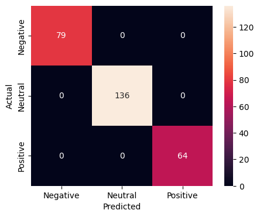

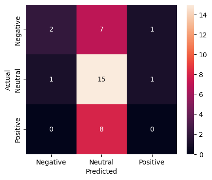

```python
plot_confusion_matrix(y_train_sentenceTransformer, y_pred_train_st)

plot_confusion_matrix(y_test_sentenceTransformer, y_pred_test_st)
```

```python
print(classification_report(y_train_sentenceTransformer, y_pred_train_st))
print(classification_report(y_test_sentenceTransformer, y_pred_test_st))
```

```
              precision    recall  f1-score   support

          -1       1.00      1.00      1.00        79
           0       1.00      1.00      1.00       136
           1       1.00      1.00      1.00        64

    accuracy                           1.00       279
   macro avg       1.00      1.00      1.00       279
weighted avg       1.00      1.00      1.00       279

              precision    recall  f1-score   support

          -1       0.67      0.20      0.31        10
           0       0.50      0.88      0.64        17
           1       0.00      0.00      0.00         8

    accuracy                           0.49        35
   macro avg       0.39      0.36      0.32        35
weighted avg       0.43      0.49      0.40        35
```

```python
# Hyperparameter tuning and retraining for Sentence Transformer

from sklearn.model_selection import GridSearchCV
from sklearn.ensemble import RandomForestClassifier

# Define parameter grid
param_grid = {
    'n_estimators': [50, 100, 200],
    'max_depth': [10, 20, None],
    'min_samples_split': [2, 5, 10],
    'min_samples_leaf': [1, 2, 4],
    'bootstrap': [True, False]
}

# Perform Grid Search
grid_search = GridSearchCV(estimator=rf_transformer, param_grid=param_grid,
                           cv=3, n_jobs=-1, verbose=2, scoring='f1_weighted')
grid_search.fit(X_train_sentenceTransformer, y_train_sentenceTransformer)

# Best parameters and performance
print("Best Parameters:", grid_search.best_params_)
print("Best Cross-Validated F1 Score:", grid_search.best_score_)
```

```
Fitting 3 folds for each of 162 candidates, totalling 486 fits
Best Parameters: {'bootstrap': True, 'max_depth': 20, 'min_samples_leaf': 1, 'min_samples_split': 10, 'n_estimators': 100}
Best Cross-Validated F1 Score: 0.3924415961563539
```

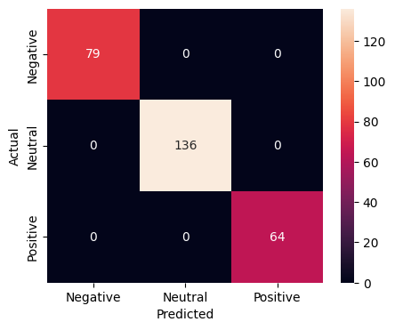

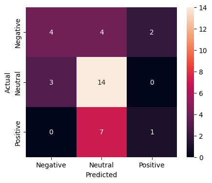

```python
# Retrain model with best parameters
best_rf_st = grid_search.best_estimator_
best_rf_st.fit(X_train_sentenceTransformer, y_train_sentenceTransformer)

# Predicting on train data
y_pred_train_st_2 = best_rf_st.predict(X_train_sentenceTransformer)

# Predicting on test data
y_pred_test_st_2 = best_rf_st.predict(X_test_sentenceTransformer)


plot_confusion_matrix(y_train_sentenceTransformer, y_pred_train_st_2)

plot_confusion_matrix(y_test_sentenceTransformer, y_pred_test_st_2)
```

```python
# Evaluate on test data
y_pred_tuned_st = best_rf_st.predict(X_test_sentenceTransformer)
print("Classification Report:")
print(classification_report(y_test_sentenceTransformer, y_pred_tuned_st))
```

```
Classification Report:
              precision    recall  f1-score   support

          -1       0.57      0.40      0.47        10
           0       0.56      0.82      0.67        17
           1       0.33      0.12      0.18         8

    accuracy                           0.54        35
   macro avg       0.49      0.45      0.44        35
weighted avg       0.51      0.54      0.50        35
```

```python
print("Classification Report:")
y_pred_tuned_st = best_rf_st.predict(X_valid_sentenceTransformer)
print(classification_report(y_valid_sentenceTransformer, y_pred_tuned_st))
```

```
Classification Report:
              precision    recall  f1-score   support

          -1       0.40      0.20      0.27        10
           0       0.46      0.76      0.58        17
           1       0.50      0.12      0.20         8

    accuracy                           0.46        35
   macro avg       0.45      0.36      0.35        35
weighted avg       0.45      0.46      0.40        35
```

Glove

```python
def confusion_matrix_sklearn(model, predictors, target):
    """
    To plot the confusion_matrix with percentages

    model: classifier
    predictors: independent variables
    target: dependent variable
    """
    y_pred = model.predict(predictors)
    cm = confusion_matrix(target, y_pred)
    labels = np.asarray(
        [
            ["{0:0.0f}".format(item) + "\n{0:.2%}".format(item / cm.flatten().sum())]
            for item in cm.flatten()
        ]
    ).reshape(cm.shape[0], cm.shape[1])

    plt.figure(figsize=(6, 4))
    sns.heatmap(cm, annot=labels, fmt="")
    plt.ylabel("True label")
    plt.xlabel("Predicted label")
```

```python
rf_glove = RandomForestClassifier(random_state = 42)

# Fitting on train data
rf_glove.fit(X_train_glove, y_train_glove)
```

```
RandomForestClassifier(random_state=42)
```

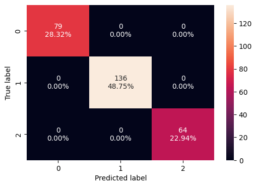

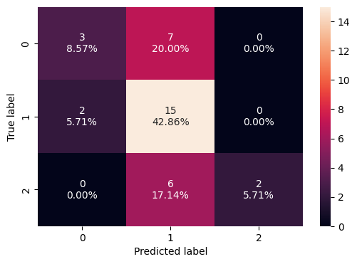

```python
confusion_matrix_sklearn(rf_glove, X_train_glove, y_train_glove)
confusion_matrix_sklearn(rf_glove, X_valid_glove, y_valid_glove)
```

```python
# Predicting on train data
y_pred_train_glove = rf_glove.predict(X_train_glove)

# Predicting on validation data
y_pred_valid_glove = rf_glove.predict(X_valid_glove)
```

```python
print(classification_report(y_train_glove, y_pred_train_glove))
print(classification_report(y_valid_glove, y_pred_valid_glove))
```

```
              precision    recall  f1-score   support

          -1       1.00      1.00      1.00        79
           0       1.00      1.00      1.00       136
           1       1.00      1.00      1.00        64

    accuracy                           1.00       279
   macro avg       1.00      1.00      1.00       279
weighted avg       1.00      1.00      1.00       279

              precision    recall  f1-score   support

          -1       0.60      0.30      0.40        10
           0       0.54      0.88      0.67        17
           1       1.00      0.25      0.40         8

    accuracy                           0.57        35
   macro avg       0.71      0.48      0.49        35
weighted avg       0.66      0.57      0.53        35
```

```python
# Hyperparameter tuning and retraining for GloVe

# Define parameter grid
param_grid = {
    'n_estimators': [50, 100, 200],
    'max_depth': [10, 20, None],
    'min_samples_split': [2, 5, 10],
    'min_samples_leaf': [1, 2, 4],
    'bootstrap': [True, False]
}

# Perform Grid Search
grid_search = GridSearchCV(estimator=rf_glove, param_grid=param_grid,
                           cv=3, n_jobs=-1, verbose=2, scoring='f1_weighted')
grid_search.fit(X_train_glove, y_train_glove)

# Best parameters and performance
print("Best Parameters:", grid_search.best_params_)
print("Best Cross-Validated F1 Score:", grid_search.best_score_)
```

```
Fitting 3 folds for each of 162 candidates, totalling 486 fits
Best Parameters: {'bootstrap': False, 'max_depth': 20, 'min_samples_leaf': 2, 'min_samples_split': 2, 'n_estimators': 50}
Best Cross-Validated F1 Score: 0.47317498024732824
```

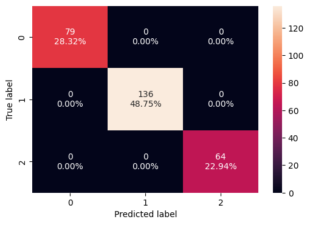

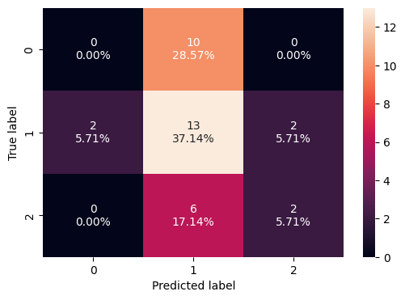

```python
# Retrain model with best parameters
best_rf_gl = grid_search.best_estimator_
best_rf_gl.fit(X_train_glove, y_train_glove)

confusion_matrix_sklearn(best_rf_gl, X_train_glove, y_train_glove)
confusion_matrix_sklearn(best_rf_gl, X_valid_glove, y_valid_glove)
```

```python
# Evaluate on test data
y_pred_tuned_gl = best_rf_gl.predict(X_test_glove)
print("Classification Report:")
print(classification_report(y_test_glove, y_pred_tuned_gl))
```

```
Classification Report:
              precision    recall  f1-score   support

          -1       0.44      0.40      0.42        10
           0       0.50      0.65      0.56        17
           1       0.50      0.25      0.33         8

    accuracy                           0.49        35
   macro avg       0.48      0.43      0.44        35
weighted avg       0.48      0.49      0.47        35
```

```python
print("Classification Report:")
print(classification_report(y_valid_glove, y_pred_tuned_gl))
```

[output not shown]

Word2Vec

```python
rf_w2v = RandomForestClassifier(random_state = 42)
rf_w2v.fit(X_train_word2vec, y_train_word2vec)
```

```
RandomForestClassifier(random_state=42)
```

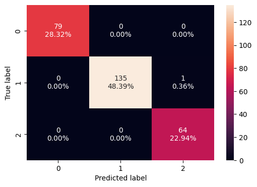

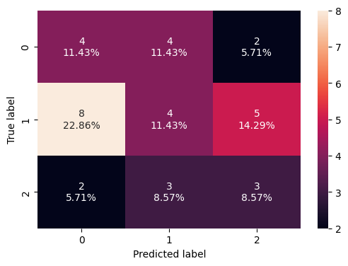

```python
confusion_matrix_sklearn(rf_w2v, X_train_word2vec, y_train_word2vec)
confusion_matrix_sklearn(rf_w2v, X_valid_word2vec, y_valid_word2vec)
```

```python
# Predicting on train data
y_pred_train_word2vec = rf_w2v.predict(X_train_word2vec)

# Predicting on validation data
y_pred_valid_word2vec = rf_w2v.predict(X_valid_word2vec)
```

```python
print(classification_report(y_train_word2vec, y_pred_train_word2vec))
print(classification_report(y_valid_word2vec, y_pred_valid_word2vec))
```

```
              precision    recall  f1-score   support

          -1       1.00      1.00      1.00        79
           0       1.00      0.99      1.00       136
           1       0.98      1.00      0.99        64

    accuracy                           1.00       279
   macro avg       0.99      1.00      1.00       279
weighted avg       1.00      1.00      1.00       279

              precision    recall  f1-score   support

          -1       0.29      0.40      0.33        10
           0       0.36      0.24      0.29        17
           1       0.30      0.38      0.33         8

    accuracy                           0.31        35
   macro avg       0.32      0.34      0.32        35
weighted avg       0.33      0.31      0.31        35
```

```python
# Hyperparameter tuning and retraining for Word2Vec

# Define parameter grid
param_grid = {
    'n_estimators': [50, 100, 200],
    'max_depth': [10, 20, None],
    'min_samples_split': [2, 5, 10],
    'min_samples_leaf': [1, 2, 4],
    'bootstrap': [True, False]
}

# Perform Grid Search
grid_search = GridSearchCV(estimator=rf_w2v, param_grid=param_grid,
                           cv=3, n_jobs=-1, verbose=2, scoring='f1_weighted')
grid_search.fit(X_train_word2vec, y_train_word2vec)

# Best parameters and performance
print("Best Parameters:", grid_search.best_params_)
print("Best Cross-Validated F1 Score:", grid_search.best_score_)
```

[output not shown]

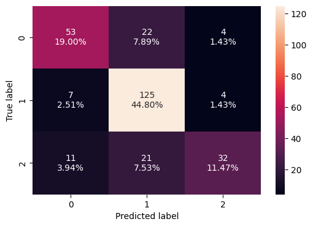

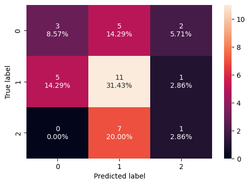

```python
# Retrain model with best parameters
best_rf_w2v = grid_search.best_estimator_
best_rf_w2v.fit(X_train_word2vec, y_train_word2vec)

confusion_matrix_sklearn(best_rf_w2v, X_train_word2vec, y_train_word2vec)
confusion_matrix_sklearn(best_rf_w2v, X_valid_word2vec, y_valid_word2vec)
```

```python
# Evaluate on test data
y_pred_tuned_w = best_rf_w2v.predict(X_test_word2vec)
print("Classification Report:")
print(classification_report(y_test_word2vec, y_pred_tuned_w))
```

```
Classification Report:
              precision    recall  f1-score   support

          -1       0.36      0.40      0.38        10
           0       0.55      0.65      0.59        17
           1       0.25      0.12      0.17         8

    accuracy                           0.46        35
   macro avg       0.39      0.39      0.38        35
weighted avg       0.43      0.46      0.44        35
```

```python
print("Classification Report:")
print(classification_report(y_valid_word2vec, y_pred_tuned_w))
```

[output not shown]

Model Selection:

```
              precision    recall  f1-score   support

          -1       0.44      0.40      0.42        10
           0       0.50      0.65      0.56        17
           1       0.50      0.25      0.33         8

    accuracy                           0.49        35
   macro avg       0.48      0.43      0.44        35
weighted avg       0.48      0.49      0.47        35
```

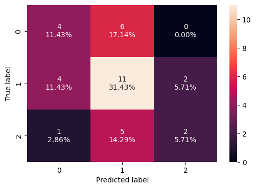

```python
confusion_matrix_sklearn(best_rf_gl, X_test_glove, y_test_glove)
print(classification_report(y_test_glove, y_pred_tuned_gl))
```

## **Weekly News Summarization**

**Important Note**: It is recommended to run this section of the project independently from the previous sections in order to avoid runtime crashes due to RAM overload.

#### Installing and Importing the necessary libraries

```python
# Installation for GPU llama-cpp-python
# uncomment and run the following code in case GPU is being used
!CMAKE_ARGS="-DLLAMA_CUBLAS=on" FORCE_CMAKE=1 pip install llama-cpp-python -q
!pip install llama-cpp-python --use-pep517

# Installation for CPU llama-cpp-python
# uncomment and run the following code in case GPU is not being used
#!CMAKE_ARGS="-DLLAMA_CUBLAS=off" FORCE_CMAKE=1 pip install llama-cpp-python -q
```

[output not shown]

```python
# Function to download the model from the Hugging Face model hub
from huggingface_hub import hf_hub_download

# Importing the Llama class from the llama_cpp module
from llama_cpp import Llama

# Importing the library for data manipulation
import pandas as pd

from tqdm import tqdm # For progress bar related functionalities
tqdm.pandas()
```

#### Loading the data

```python
filepath = '/content/drive/My Drive/stock_news.csv'
df2 = pd.read_csv(filepath)
```

#### Loading the model

```python
model_name_or_path = "TheBloke/Mistral-7B-Instruct-v0.2-GGUF"
model_basename = "mistral-7b-instruct-v0.2.Q6_K.gguf"
```

```python
model_path = hf_hub_download(
    repo_id=model_name_or_path,
    filename=model_basename
)
```

```python
llm = Llama(
    model_path=model_path,
    n_gpu_layers=100,
    n_ctx=4500,
)
```

[output not shown]

[output cut: 84 more lines]

[output not shown]

#### Aggregating the data weekly

```python
df2["Date"] = pd.to_datetime(df2['Date'])  # Convert the 'Date' column to datetime format.
```

```python
# Group the data by week using the 'Date' column.
weekly_grouped = df2.groupby(pd.Grouper(key='Date', freq='W'))
```

```python
weekly_grouped = weekly_grouped.agg(
    {
        'News': lambda x: ' || '.join(x)  # Join the news values with ' || ' separator.
    }
).reset_index()

print(weekly_grouped.shape)
```

```
(18, 2)
```

```python
weekly_grouped
```

|  | Date | News |
| --- | --- | --- |
| 0 | 2019-01-06 | The tech sector experienced a significant dec... |
| 1 | 2019-01-13 | Sprint and Samsung plan to release 5G smartph... |
| 2 | 2019-01-20 | The U.S. stock market declined on Monday as c... |
| 3 | 2019-01-27 | The Swiss National Bank (SNB) governor, Andre... |
| 4 | 2019-02-03 | Caterpillar Inc reported lower-than-expected ... |
| 5 | 2019-02-10 | The Dow Jones Industrial Average, S&P 500, an... |
| 6 | 2019-02-17 | This week, the European Union's second highes... |
| 7 | 2019-02-24 | This news article discusses progress towards ... |
| 8 | 2019-03-03 | The Dow Jones Industrial Average and other ma... |
| 9 | 2019-03-10 | Spotify, the world's largest paid music strea... |
| 10 | 2019-03-17 | The United States opposes France's digital se... |
| 11 | 2019-03-24 | Facebook's stock price dropped more than 3% o... |
| 12 | 2019-03-31 | This news article reports that the S&P 500 In... |
| 13 | 2019-04-07 | Apple and other consumer brands, including LV... |
| 14 | 2019-04-14 | In March, mobile phone shipments to China dro... |
| 15 | 2019-04-21 | The chairman of Taiwan's Foxconn, Terry Gou, ... |
| 16 | 2019-04-28 | Taiwan's export orders continued to decline f... |
| 17 | 2019-05-05 | Spotify reported better-than-expected Q1 reve... |

```python
# creating a copy of the data
data_1 = weekly_grouped.copy()
```

#### Summarization

**Note**:

- The model is expected to summarize the news from the week by identifying the top three positive and negative events that are most likely to impact the price of the stock.
- As an output, the model is expected to return a JSON containing two keys, one for Positive Events and one for Negative Events.

For the project, we need to define the prompt to be fed to the LLM to help it understand the task to perform. The following should be the components of the prompt:

1. **Role**: Specifies the role the LLM will be taking up to perform the specified task, along with any specific details regarding the role
   - **Example**: `You are an expert data analyst specializing in news content analysis.`
2. **Task**: Specifies the task to be performed and outlines what needs to be accomplished, clearly defining the objective
   - **Example**: `Analyze the provided news headline and return the main topics contained within it.`
3. **Instructions**: Provides detailed guidelines on how to perform the task, which includes steps, rules, and criteria to ensure the task is executed correctly
   - **Example**:

```
Instructions:
1. Read the news headline carefully.
2. Identify the main subjects or entities mentioned in the headline.
3. Determine the key events or actions described in the headline.
4. Extract relevant keywords that represent the topics.
5. List the topics in a concise manner.
```

1. **Output Format**: Specifies the format in which the final response should be structured, ensuring consistency and clarity in the generated output
   - **Example**: `Return the output in JSON format with keys as the topic number and values as the actual topic.`

**Full Prompt Example**:

```
You are an expert data analyst specializing in news content analysis.

Task: Analyze the provided news headline and return the main topics contained within it.

Instructions:
1. Read the news headline carefully.
2. Identify the main subjects or entities mentioned in the headline.
3. Determine the key events or actions described in the headline.
4. Extract relevant keywords that represent the topics.
5. List the topics in a concise manner.

Return the output in JSON format with keys as the topic number and values as the actual topic.
```

**Sample Output**:

`{"1": "Politics", "2": "Economy", "3": "Health" }`

##### Utility Functions

```python
# defining a function to parse the JSON output from the model
def extract_json_data(json_str):
    import json
    try:
        # Find the indices of the opening and closing curly braces
        json_start = json_str.find('{')
        json_end = json_str.rfind('}')

        if json_start != -1 and json_end != -1:
            extracted_category = json_str[json_start:json_end + 1]  # Extract the JSON object
            data_dict = json.loads(extracted_category)
            return data_dict
        else:
            print(f"Warning: JSON object not found in response: {json_str}")
            return {}
    except json.JSONDecodeError as e:
        print(f"Error parsing JSON: {e}")
        return {}
```

##### Defining the response function

```python
#Defining the response function
def response_mistral_1(prompt, news):
    model_output = llm(
      f"""
      [INST]
      {prompt}
      News Articles: {news}
      [/INST]
      """,
      max_tokens=400,
      temperature=0.05,
      top_p=0.9,
      top_k=40,
      echo=False,
    )

    final_output = model_output["choices"][0]["text"]

    return final_output
```

```python
df2.head(1)
```

|  | Date | News | Open | High | Low | Close | Volume | Label |
| --- | --- | --- | --- | --- | --- | --- | --- | --- |
| 0 | 2019-01-02 | The tech sector experienced a significant dec... | 41.740002 | 42.244999 | 41.482498 | 40.246914 | 130672400 | -1 |

##### Checking the model output on a sample

**Note**: Use this section to test out the prompt with one instance before using it for the entire weekly data.

```python
prompt = """
  You're an expert in stock market news summarization
  You'll be provided with news articles separated by '||',
  Read through the articles and extract the 3 biggest positive and 3 biggest negative aspects that could potentially impact stock performance
  Consider factors like market trends, company announcements, economic indicators and other relevant news
  Return the output in JSON format in the following format:
  {"Positive Aspects" : [Aspect 1, Aspect 2, Aspect 3], "Negative Aspects": [Aspect 1, Aspect 2, Aspect 3]}
  Return only the JSON and nothing else
"""
```

```python
news = data_1['News'].iloc[0]
print(len(news.split(' ')))
```

```
2611
```

```python
summary = response_mistral_1(prompt, news)
summary
```

```
Llama.generate: 512 prefix-match hit, remaining 3393 prompt tokens to eval
llama_perf_context_print:        load time = 1557754.78 ms
llama_perf_context_print: prompt eval time =       0.00 ms /  4417 tokens (    0.00 ms per token,      inf tokens per second)
llama_perf_context_print:        eval time =       0.00 ms /   252 runs   (    0.00 ms per token,      inf tokens per second)
llama_perf_context_print:       total time = 1801272.05 ms /  4669 tokens
```

```
'{"Positive Aspects" : ["Roku Inc\'s plan to offer premium video channels on a subscription basis through its free streaming service, The Roku Channel", "European stock markets rallied following positive trade war talks between Beijing and Washington, specifically sectors sensitive to the trade war …
```

##### Checking the model output on the weekly data

```python
data_1['Key Events']= data_1['News'].progress_apply(lambda x: response_mistral_1(prompt, x))
```

[output not shown]

##### Formatting the model output

```python
data_1['Key Events'].head(5)
data_1['Parsed Response'] = data_1['Key Events'].apply(extract_json_data)
```

[output not shown]

```python
parsed_response = pd.json_normalize(data_1['Parsed Response'])
parsed_response.head(5)
```

[output not shown]

```python
final = pd.concat([data_1.reset_index(drop=True), parsed_response], axis=1)
final.drop(['Parsed Response','Key Events'],axis = 1, inplace=True)
final.columns = ['Date', 'News', 'Positive Aspects', 'Negative Aspects']
final.head(5)
```

[output not shown]